# Data Wrangling Training

Iwen Su

3/6/2018

## Intro to Data Wrangling: `dplyr`

### Wrangle gapminder data using `dplyr`.

First load the packages.

```r
library(tidyverse)
library(skimr)
```

### Get data from github.

```r
gapminder <- readr::read_csv("https://raw.githubusercontent.com/OHI-Science/data-science-training/master/data/gapminder.csv")
```

### Explore gapminder data.

```r
head(gapminder)
```

```
## # A tibble: 6 x 6
##   country      year      pop continent lifeExp gdpPercap
##   <chr>       <int>    <dbl> <chr>       <dbl>     <dbl>
## 1 Afghanistan  1952  8425333 Asia         28.8       779
## 2 Afghanistan  1957  9240934 Asia         30.3       821
## 3 Afghanistan  1962 10267083 Asia         32.0       853
## 4 Afghanistan  1967 11537966 Asia         34.0       836
## 5 Afghanistan  1972 13079460 Asia         36.1       740
## 6 Afghanistan  1977 14880372 Asia         38.4       786
```

```r
tail(gapminder)
```

```
## # A tibble: 6 x 6
##   country   year      pop continent lifeExp gdpPercap
##   <chr>    <int>    <dbl> <chr>       <dbl>     <dbl>
## 1 Zimbabwe  1982  7636524 Africa       60.4       789
## 2 Zimbabwe  1987  9216418 Africa       62.4       706
## 3 Zimbabwe  1992 10704340 Africa       60.4       693
## 4 Zimbabwe  1997 11404948 Africa       46.8       792
## 5 Zimbabwe  2002 11926563 Africa       40.0       672
## 6 Zimbabwe  2007 12311143 Africa       43.5       470
```

```r
head(gapminder, 10) # see the first ten rows
```

```
## # A tibble: 10 x 6
##    country      year      pop continent lifeExp gdpPercap
##    <chr>       <int>    <dbl> <chr>       <dbl>     <dbl>
##  1 Afghanistan  1952  8425333 Asia         28.8       779
##  2 Afghanistan  1957  9240934 Asia         30.3       821
##  3 Afghanistan  1962 10267083 Asia         32.0       853
##  4 Afghanistan  1967 11537966 Asia         34.0       836
##  5 Afghanistan  1972 13079460 Asia         36.1       740
##  6 Afghanistan  1977 14880372 Asia         38.4       786
##  7 Afghanistan  1982 12881816 Asia         39.9       978
##  8 Afghanistan  1987 13867957 Asia         40.8       852
##  9 Afghanistan  1992 16317921 Asia         41.7       649
## 10 Afghanistan  1997 22227415 Asia         41.8       635
```

```r
tail(gapminder, 12) # see the last twelve rows
```

```
## # A tibble: 12 x 6
##    country   year      pop continent lifeExp gdpPercap
##    <chr>    <int>    <dbl> <chr>       <dbl>     <dbl>
##  1 Zimbabwe  1952  3080907 Africa       48.5       407
##  2 Zimbabwe  1957  3646340 Africa       50.5       519
##  3 Zimbabwe  1962  4277736 Africa       52.4       527
##  4 Zimbabwe  1967  4995432 Africa       54.0       570
##  5 Zimbabwe  1972  5861135 Africa       55.6       799
##  6 Zimbabwe  1977  6642107 Africa       57.7       686
##  7 Zimbabwe  1982  7636524 Africa       60.4       789
##  8 Zimbabwe  1987  9216418 Africa       62.4       706
##  9 Zimbabwe  1992 10704340 Africa       60.4       693
## 10 Zimbabwe  1997 11404948 Africa       46.8       792
## 11 Zimbabwe  2002 11926563 Africa       40.0       672
## 12 Zimbabwe  2007 12311143 Africa       43.5       470
```

```r
## See structure and other info about the data frame
str(gapminder)
```

```
## Classes 'tbl_df', 'tbl' and 'data.frame':    1704 obs. of  6 variables:
##  $ country  : chr  "Afghanistan" "Afghanistan" "Afghanistan" "Afghanistan" ...
##  $ year     : int  1952 1957 1962 1967 1972 1977 1982 1987 1992 1997 ...
##  $ pop      : num  8425333 9240934 10267083 11537966 13079460 ...
##  $ continent: chr  "Asia" "Asia" "Asia" "Asia" ...
##  $ lifeExp  : num  28.8 30.3 32 34 36.1 ...
##  $ gdpPercap: num  779 821 853 836 740 ...
##  - attr(*, "spec")=List of 2
##   ..$ cols   :List of 6
##   .. ..$ country  : list()
##   .. .. ..- attr(*, "class")= chr  "collector_character" "collector"
##   .. ..$ year     : list()
##   .. .. ..- attr(*, "class")= chr  "collector_integer" "collector"
##   .. ..$ pop      : list()
##   .. .. ..- attr(*, "class")= chr  "collector_double" "collector"
##   .. ..$ continent: list()
##   .. .. ..- attr(*, "class")= chr  "collector_character" "collector"
##   .. ..$ lifeExp  : list()
##   .. .. ..- attr(*, "class")= chr  "collector_double" "collector"
##   .. ..$ gdpPercap: list()
##   .. .. ..- attr(*, "class")= chr  "collector_double" "collector"
##   ..$ default: list()
##   .. ..- attr(*, "class")= chr  "collector_guess" "collector"
##   ..- attr(*, "class")= chr "col_spec"
```

```r
names(gapminder)
```

```
## [1] "country"   "year"      "pop"       "continent" "lifeExp"   "gdpPercap"
```

```r
dim(gapminder)
```

```
## [1] 1704    6
```

```r
c(nrow(gapminder), ncol(gapminder)) # create dim() from nrow() and ncol()
```

```
## [1] 1704    6
```

```r
## summary statistics
summary(gapminder)
```

```
##    country               year           pop             continent
##  Length:1704        Min.   :1952   Min.   :6.001e+04   Length:1704
##  Class :character   1st Qu.:1966   1st Qu.:2.794e+06   Class :character
##  Mode  :character   Median :1980   Median :7.024e+06   Mode  :character
##                     Mean   :1980   Mean   :2.960e+07
##                     3rd Qu.:1993   3rd Qu.:1.959e+07
##                     Max.   :2007   Max.   :1.319e+09
##     lifeExp        gdpPercap
##  Min.   :23.60   Min.   :   241.2
##  1st Qu.:48.20   1st Qu.:  1202.1
##  Median :60.71   Median :  3531.8
##  Mean   :59.47   Mean   :  7215.3
##  3rd Qu.:70.85   3rd Qu.:  9325.5
##  Max.   :82.60   Max.   :113523.1
```

```r
skim(gapminder)
```

```
## Skim summary statistics
##  n obs: 1704
##  n variables: 6
##
## Variable type: character
##   variable missing complete    n min max empty n_unique
##  continent       0     1704 1704   4   8     0        5
##    country       0     1704 1704   4  24     0      142
##
## Variable type: integer
##  variable missing complete    n   mean    sd   p0     p25 median     p75
##      year       0     1704 1704 1979.5 17.27 1952 1965.75 1979.5 1993.25
##  p100     hist
##  2007 ▇▃▇▃▃▇▃▇
##
## Variable type: numeric
##   variable missing complete    n     mean         sd       p0        p25
##  gdpPercap       0     1704 1704  7215.33 9857.45      241.17    1202.06
##    lifeExp       0     1704 1704    59.47   12.92       23.6       48.2
##        pop       0     1704 1704 3e+07       1.1e+08 60011    2793664
##    median      p75         p100     hist
##   3531.85  9325.46 113523.13    ▇▁▁▁▁▁▁▁
##     60.71    70.85     82.6     ▁▂▅▅▅▅▇▃
##  7e+06    2e+07         1.3e+09 ▇▁▁▁▁▁▁▁
```

> Note: In addition to what data.frames can store, tibble can store lists, ggplots, and multiple dataframes.

Explore inside the dataframe `$`

```r
head(gapminder$lifeExp, 10)
```

```
##  [1] 28.801 30.332 31.997 34.020 36.088 38.438 39.854 40.822 41.674 41.763
```

```r
str(gapminder$lifeExp) # more useful function for looking at entire dataset
```

```
##  num [1:1704] 28.8 30.3 32 34 36.1 ...
```

```r
summary(gapminder$lifeExp)
```

```
##    Min. 1st Qu.  Median    Mean 3rd Qu.    Max.
##   23.60   48.20   60.71   59.47   70.85   82.60
```

```r
skim(gapminder$lifeExp)
```

```
## Skim summary statistics
##
## Variable type: numeric
##           variable missing complete    n  mean    sd   p0  p25 median
##  gapminder$lifeExp       0     1704 1704 59.47 12.92 23.6 48.2  60.71
##    p75 p100     hist
##  70.85 82.6 ▁▂▅▅▅▅▇▃
```

### Dplyr basics:

Main functions include: `filter()`, `select()`, `mutate()`, `summarise()`, and `arrange()`. See dplyr [cheatsheet](http://www.rstudio.com/wp-content/uploads/2015/02/data-wrangling-cheatsheet.pdf).

```r
filter(gapminder, lifeExp < 29)
```

```
## # A tibble: 2 x 6
##   country      year     pop continent lifeExp gdpPercap
##   <chr>       <int>   <dbl> <chr>       <dbl>     <dbl>
## 1 Afghanistan  1952 8425333 Asia         28.8       779
## 2 Rwanda       1992 7290203 Africa       23.6       737
```

```r
# Filter for 1 country
filter(gapminder, country == "Mexico")
```

```
## # A tibble: 12 x 6
##    country  year       pop continent lifeExp gdpPercap
##    <chr>   <int>     <dbl> <chr>       <dbl>     <dbl>
##  1 Mexico   1952  30144317 Americas     50.8      3478
##  2 Mexico   1957  35015548 Americas     55.2      4132
##  3 Mexico   1962  41121485 Americas     58.3      4582
##  4 Mexico   1967  47995559 Americas     60.1      5755
##  5 Mexico   1972  55984294 Americas     62.4      6809
##  6 Mexico   1977  63759976 Americas     65.0      7675
##  7 Mexico   1982  71640904 Americas     67.4      9611
##  8 Mexico   1987  80122492 Americas     69.5      8688
##  9 Mexico   1992  88111030 Americas     71.5      9472
## 10 Mexico   1997  95895146 Americas     73.7      9767
## 11 Mexico   2002 102479927 Americas     74.9     10742
## 12 Mexico   2007 108700891 Americas     76.2     11978
```

```r
# Filter for multiple countries - use the `%in%` operator on `c()`
filter(gapminder, country %in% c("Mexico", "Chile"))
```

```
## # A tibble: 24 x 6
##    country  year      pop continent lifeExp gdpPercap
##    <chr>   <int>    <dbl> <chr>       <dbl>     <dbl>
##  1 Chile    1952  6377619 Americas     54.7      3940
##  2 Chile    1957  7048426 Americas     56.1      4316
##  3 Chile    1962  7961258 Americas     57.9      4519
##  4 Chile    1967  8858908 Americas     60.5      5107
##  5 Chile    1972  9717524 Americas     63.4      5494
##  6 Chile    1977 10599793 Americas     67.1      4757
##  7 Chile    1982 11487112 Americas     70.6      5096
##  8 Chile    1987 12463354 Americas     72.5      5547
##  9 Chile    1992 13572994 Americas     74.1      7596
## 10 Chile    1997 14599929 Americas     75.8     10118
## # ... with 14 more rows
```

```r
# Filter for 1 country in a specific year
filter(gapminder, country == "Mexico", year == 2002)
```

```
## # A tibble: 1 x 6
##   country  year       pop continent lifeExp gdpPercap
##   <chr>   <int>     <dbl> <chr>       <dbl>     <dbl>
## 1 Mexico   2002 102479927 Americas     74.9     10742
```

```r
# Select by columns
select(gapminder, year, lifeExp)
```

```
## # A tibble: 1,704 x 2
##     year lifeExp
##    <int>   <dbl>
##  1  1952    28.8
##  2  1957    30.3
##  3  1962    32.0
##  4  1967    34.0
##  5  1972    36.1
##  6  1977    38.4
##  7  1982    39.9
##  8  1987    40.8
##  9  1992    41.7
## 10  1997    41.8
## # ... with 1,694 more rows
```

```r
# Use the `-` to deselect columns
select(gapminder, -continent, -lifeExp)
```

```
## # A tibble: 1,704 x 4
##    country      year      pop gdpPercap
##    <chr>       <int>    <dbl>     <dbl>
##  1 Afghanistan  1952  8425333       779
##  2 Afghanistan  1957  9240934       821
##  3 Afghanistan  1962 10267083       853
##  4 Afghanistan  1967 11537966       836
##  5 Afghanistan  1972 13079460       740
##  6 Afghanistan  1977 14880372       786
##  7 Afghanistan  1982 12881816       978
##  8 Afghanistan  1987 13867957       852
##  9 Afghanistan  1992 16317921       649
## 10 Afghanistan  1997 22227415       635
## # ... with 1,694 more rows
```

```r
# Use filter and select together
gap_cambodia <- filter(gapminder, country == "Cambodia")
gap_cambodia2 <- select(gap_cambodia, -lifeExp, -continent)
```

### Life changing pipe operator `%>%` (and then)

```r
gapminder %>% head() # equivalent to head(gapminder)
```

```
## # A tibble: 6 x 6
##   country      year      pop continent lifeExp gdpPercap
##   <chr>       <int>    <dbl> <chr>       <dbl>     <dbl>
## 1 Afghanistan  1952  8425333 Asia         28.8       779
## 2 Afghanistan  1957  9240934 Asia         30.3       821
## 3 Afghanistan  1962 10267083 Asia         32.0       853
## 4 Afghanistan  1967 11537966 Asia         34.0       836
## 5 Afghanistan  1972 13079460 Asia         36.1       740
## 6 Afghanistan  1977 14880372 Asia         38.4       786
```

```r
gapminder %>% head(3) # equivalent to head(gapminder, 3)
```

```
## # A tibble: 3 x 6
##   country      year      pop continent lifeExp gdpPercap
##   <chr>       <int>    <dbl> <chr>       <dbl>     <dbl>
## 1 Afghanistan  1952  8425333 Asia         28.8       779
## 2 Afghanistan  1957  9240934 Asia         30.3       821
## 3 Afghanistan  1962 10267083 Asia         32.0       853
```

```r
# Use filter and select together
gap_cambodia <- filter(gapminder, country == "Cambodia")
gap_cambodia2 <- select(gap_cambodia, -lifeExp, -continent)

# now let's do that with the %>% operator
gap_cambodia <- gapminder %>%
  filter(country == "Cambodia")

gap_cambodia2 <- gap_cambodia %>%
  select(-lifeExp, -continent)

# or you could combine the two variables created above by stacking `%>%` operators
gap_cambodia3 <- gapminder %>%
  filter(country == "Cambodia") %>%
  select(-continent, -lifeExp)
```

### To add variables use `mutate()`

- You can run other functions inside the `mutate()` function
- You can also run mathematical operations on existing columns

```r
gapminder %>%
  mutate(index = 1:nrow(gapminder))
```

```
## # A tibble: 1,704 x 7
##    country      year      pop continent lifeExp gdpPercap index
##    <chr>       <int>    <dbl> <chr>       <dbl>     <dbl> <int>
##  1 Afghanistan  1952  8425333 Asia         28.8       779     1
##  2 Afghanistan  1957  9240934 Asia         30.3       821     2
##  3 Afghanistan  1962 10267083 Asia         32.0       853     3
##  4 Afghanistan  1967 11537966 Asia         34.0       836     4
##  5 Afghanistan  1972 13079460 Asia         36.1       740     5
##  6 Afghanistan  1977 14880372 Asia         38.4       786     6
##  7 Afghanistan  1982 12881816 Asia         39.9       978     7
##  8 Afghanistan  1987 13867957 Asia         40.8       852     8
##  9 Afghanistan  1992 16317921 Asia         41.7       649     9
## 10 Afghanistan  1997 22227415 Asia         41.8       635    10
## # ... with 1,694 more rows
```

```r
gapminder %>%
  mutate(gdp = pop*gdpPercap) # can't call 'pop' or 'gdpPercap' by itself
```

```
## # A tibble: 1,704 x 7
##    country      year      pop continent lifeExp gdpPercap         gdp
##    <chr>       <int>    <dbl> <chr>       <dbl>     <dbl>       <dbl>
##  1 Afghanistan  1952  8425333 Asia         28.8       779  6567086330
##  2 Afghanistan  1957  9240934 Asia         30.3       821  7585448670
##  3 Afghanistan  1962 10267083 Asia         32.0       853  8758855797
##  4 Afghanistan  1967 11537966 Asia         34.0       836  9648014150
##  5 Afghanistan  1972 13079460 Asia         36.1       740  9678553274
##  6 Afghanistan  1977 14880372 Asia         38.4       786 11697659231
##  7 Afghanistan  1982 12881816 Asia         39.9       978 12598563401
##  8 Afghanistan  1987 13867957 Asia         40.8       852 11820990309
##  9 Afghanistan  1992 16317921 Asia         41.7       649 10595901589
## 10 Afghanistan  1997 22227415 Asia         41.8       635 14121995875
## # ... with 1,694 more rows
```

### Exercise: Find the maximum gdpPercap of Egypt and Vietnam, and save it in a new column

1. First filter for Egypt and Vietnam
2. Then use `mutate` to create a new column that has the max GDP between Egypt and Vietnam together
3. What if we want the max GDP of Egypt and max GDP of Vietnam separately? Use `group_by`

```r
# Find max GDP per capita of both Egypt and Vietnam
gapminder %>%
  filter(country %in% c("Egypt","Vietnam")) %>%
  mutate(max_gdp = max(gdpPercap))
```

```
## # A tibble: 24 x 7
##    country  year      pop continent lifeExp gdpPercap max_gdp
##    <chr>   <int>    <dbl> <chr>       <dbl>     <dbl>   <dbl>
##  1 Egypt    1952 22223309 Africa       41.9      1419    5581
##  2 Egypt    1957 25009741 Africa       44.4      1459    5581
##  3 Egypt    1962 28173309 Africa       47.0      1693    5581
##  4 Egypt    1967 31681188 Africa       49.3      1815    5581
##  5 Egypt    1972 34807417 Africa       51.1      2024    5581
##  6 Egypt    1977 38783863 Africa       53.3      2785    5581
##  7 Egypt    1982 45681811 Africa       56.0      3504    5581
##  8 Egypt    1987 52799062 Africa       59.8      3885    5581
##  9 Egypt    1992 59402198 Africa       63.7      3795    5581
## 10 Egypt    1997 66134291 Africa       67.2      4173    5581
## # ... with 14 more rows
```

```r
# Find max GDP per capita of Egypt and Vietnam separately
x2 <- gapminder %>%
  filter(country %in% c("Egypt","Vietnam")) %>%
  group_by(country) %>%
  mutate(max_gdp = max(gdpPercap)) %>%
  ungroup() # important to remember to ungroup

str(x2)
```

```
## Classes 'tbl_df', 'tbl' and 'data.frame':    24 obs. of  7 variables:
##  $ country  : chr  "Egypt" "Egypt" "Egypt" "Egypt" ...
##  $ year     : int  1952 1957 1962 1967 1972 1977 1982 1987 1992 1997 ...
##  $ pop      : num  22223309 25009741 28173309 31681188 34807417 ...
##  $ continent: chr  "Africa" "Africa" "Africa" "Africa" ...
##  $ lifeExp  : num  41.9 44.4 47 49.3 51.1 ...
##  $ gdpPercap: num  1419 1459 1693 1815 2024 ...
##  $ max_gdp  : num  5581 5581 5581 5581 5581 ...
```

### Summarize and `group_by` together

While it can be nice to replicate the `max_gdp` value for each observation especially when you are running commands on all the observations, you may also want to just select the single value of max gdp for each country.

> Note: ‘CTRL+I’ is the shortcut for reindenting lines.

```r
gapminder %>%
  group_by(country) %>%
  mutate(gdp = pop*gdpPercap) %>%
  summarize(max_gdp = max(gdp)) %>%
  ungroup() %>%
  arrange(max_gdp) # ascending order
```

```
## # A tibble: 142 x 2
##    country                     max_gdp
##    <chr>                         <dbl>
##  1 Sao Tome and Principe     319014077
##  2 Comoros                   701111696
##  3 Guinea-Bissau             950984749
##  4 Djibouti                 1033689705
##  5 Gambia                   1270911775
##  6 Liberia                  1495937378
##  7 Central African Republic 3084613079
##  8 Lesotho                  3158513357
##  9 Burundi                  3669693671
## 10 Eritrea                  3707155863
## # ... with 132 more rows
```

```r
gapminder %>%
  group_by(country) %>%
  mutate(gdp = pop*gdpPercap) %>%
  summarize(max_gdp = max(gdp)) %>%
  ungroup() %>%
  arrange(desc(max_gdp)) # descending order
```

```
## # A tibble: 142 x 2
##    country               max_gdp
##    <chr>                   <dbl>
##  1 United States  12934458535085
##  2 China           6539500929092
##  3 Japan           4035134797102
##  4 India           2722925438773
##  5 Germany         2650870893901
##  6 United Kingdom  2017969309929
##  7 France          1861227940621
##  8 Brazil          1722598680331
##  9 Italy           1661264433000
## 10 Mexico          1301973070171
## # ... with 132 more rows
```

Let’s find the max lifeExp for countries in Asia

```r
# Grab max GDP for just countries in Asia
asia <- gapminder %>%
  filter(continent == "Asia") %>%
  group_by(country) %>%
  mutate(gdp = pop*gdpPercap) %>%
  summarize(max_gdp = max(gdp)) %>%
  ungroup() %>%
  arrange(desc(max_gdp)) # descending order

# Grab max life expectancy for countries in Asia
gapminder %>%
  filter(continent == "Asia") %>%
  group_by(country) %>%
  summarize(max_gdp = max(lifeExp)) %>%
  ungroup() %>%
  dplyr::arrange(desc(max_gdp)) # descending order
```

```
## # A tibble: 33 x 2
##    country         max_gdp
##    <chr>             <dbl>
##  1 Japan              82.6
##  2 Hong Kong China    82.2
##  3 Israel             80.7
##  4 Singapore          80.0
##  5 Korea Rep.         78.6
##  6 Taiwan             78.4
##  7 Kuwait             77.6
##  8 Oman               75.6
##  9 Bahrain            75.6
## 10 Vietnam            74.2
## # ... with 23 more rows
```

### Joining Datasets

Also referred to as relational data, because there is a relationship between two or more data tables. An example is that the same column header (variable) exists in both data tables.

- You have to decide which data table you want to maintain the observations for, as they may share the same column header, but all the observations may not have match for each observation
- `left_join` and `right_join` can be used to determine whether you want to maintain the integrity of data table on the left (first argument value) or on the right (second argument value) in the function
- `inner_join` keeps only matched rows between both data tables
- `full_join` retains all rows even if there are no matches

```r
# Bring in second data table that will be joined with the `gapminder` dataset
co2 <- read_csv("https://raw.githubusercontent.com/OHI-Science/data-science-training/master/data/co2.csv")
# explore
co2 %>%
  head()
```

```
## # A tibble: 6 x 2
##   country        co2_2007
##   <chr>             <dbl>
## 1 Afghanistan      2938
## 2 Albania          4218
## 3 Algeria        105838
## 4 American Samoa     18.4
## 5 Angola          17405
## 6 Anguilla           12.4
```

```r
# Select for only 2007 data since co2 data is only from that year
gap2007 <- gapminder %>%
  filter(year == 2007)

# Left_join gap2007 to co2, by which column?
lj <- left_join(gap2007, co2, by = "country")

# Explore lj
lj %>% dim()
```

```
## [1] 142   7
```

```r
lj %>% summary()
```

```
##    country               year           pop             continent
##  Length:142         Min.   :2007   Min.   :1.996e+05   Length:142
##  Class :character   1st Qu.:2007   1st Qu.:4.508e+06   Class :character
##  Mode  :character   Median :2007   Median :1.052e+07   Mode  :character
##                     Mean   :2007   Mean   :4.402e+07
##                     3rd Qu.:2007   3rd Qu.:3.121e+07
##                     Max.   :2007   Max.   :1.319e+09
##
##     lifeExp        gdpPercap          co2_2007
##  Min.   :39.61   Min.   :  277.6   Min.   :  2938
##  1st Qu.:57.16   1st Qu.: 1624.8   1st Qu.: 10811
##  Median :71.94   Median : 6124.4   Median : 75961
##  Mean   :67.01   Mean   :11680.1   Mean   :115407
##  3rd Qu.:76.41   3rd Qu.:18008.8   3rd Qu.:140686
##  Max.   :82.60   Max.   :49357.2   Max.   :425957
##                                    NA's   :135
```

```r
# Right_join gap2007 to co2, by which column?
rj <- right_join(gap2007, co2, by = "country")

# Explore rj
rj %>% dim()
```

```
## [1] 12  7
```

```r
rj %>% summary()
```

```
##    country               year           pop            continent
##  Length:12          Min.   :2007   Min.   : 3600523   Length:12
##  Class :character   1st Qu.:2007   1st Qu.:10310130   Class :character
##  Mode  :character   Median :2007   Median :20434176   Mode  :character
##                     Mean   :2007   Mean   :21454289
##                     3rd Qu.:2007   3rd Qu.:32611570
##                     Max.   :2007   Max.   :40301927
##                     NA's   :5      NA's   :5
##     lifeExp        gdpPercap          co2_2007
##  Min.   :42.73   Min.   :  974.6   Min.   :    12.4
##  1st Qu.:58.06   1st Qu.: 5367.1   1st Qu.:  2274.0
##  Median :75.32   Median : 6223.4   Median : 11370.6
##  Mean   :67.38   Mean   :14467.6   Mean   : 70127.8
##  3rd Qu.:78.13   3rd Qu.:23607.4   3rd Qu.: 83430.6
##  Max.   :81.23   Max.   :36126.5   Max.   :425956.6
##  NA's   :5       NA's   :5
```

## Intro to Data Wrangling: `tidyr`

Data wrangling with `tidyr`, which is part of the tidyverse. We are going to tidy some data!

### Load `tidyverse`

```r
library(tidyverse) # install.packages("tidyverse")
```

### Read in gapminder dataset wide and long

*ID variables* (key) are those that identify an observation such as continent, country or year. *Observation variables* (value) are values of the observation such as population, life expectancy and gdp per capita.

```r
# wide format
gap_wide <- readr::read_csv("https://raw.githubusercontent.com/OHI-Science/data-science-training/master/data/gapminder_wide.csv")

## long format (intermediate)
gapminder <- readr::read_csv('https://raw.githubusercontent.com/OHI-Science/data-science-training/master/data/gapminder.csv')
```

### Take a look

```r
head(gap_wide)
```

```
## # A tibble: 6 x 38
##   continent country      gdpPercap_1952 gdpPercap_1957 gdpPercap_1962
##   <chr>     <chr>                 <dbl>          <dbl>          <dbl>
## 1 Africa    Algeria                2449           3014           2551
## 2 Africa    Angola                 3521           3828           4269
## 3 Africa    Benin                  1063            960            949
## 4 Africa    Botswana                851            918            984
## 5 Africa    Burkina Faso            543            617            723
## 6 Africa    Burundi                 339            380            355
## # ... with 33 more variables: gdpPercap_1967 <dbl>, gdpPercap_1972 <dbl>,
## #   gdpPercap_1977 <dbl>, gdpPercap_1982 <dbl>, gdpPercap_1987 <dbl>,
## #   gdpPercap_1992 <dbl>, gdpPercap_1997 <dbl>, gdpPercap_2002 <dbl>,
## #   gdpPercap_2007 <dbl>, lifeExp_1952 <dbl>, lifeExp_1957 <dbl>,
## #   lifeExp_1962 <dbl>, lifeExp_1967 <dbl>, lifeExp_1972 <dbl>,
## #   lifeExp_1977 <dbl>, lifeExp_1982 <dbl>, lifeExp_1987 <dbl>,
## #   lifeExp_1992 <dbl>, lifeExp_1997 <dbl>, lifeExp_2002 <dbl>,
## #   lifeExp_2007 <dbl>, pop_1952 <dbl>, pop_1957 <dbl>, pop_1962 <dbl>,
## #   pop_1967 <dbl>, pop_1972 <dbl>, pop_1977 <dbl>, pop_1982 <dbl>,
## #   pop_1987 <dbl>, pop_1992 <dbl>, pop_1997 <dbl>, pop_2002 <int>,
## #   pop_2007 <int>
```

```r
str(gap_wide)
```

```
## Classes 'tbl_df', 'tbl' and 'data.frame':    142 obs. of  38 variables:
##  $ continent     : chr  "Africa" "Africa" "Africa" "Africa" ...
##  $ country       : chr  "Algeria" "Angola" "Benin" "Botswana" ...
##  $ gdpPercap_1952: num  2449 3521 1063 851 543 ...
##  $ gdpPercap_1957: num  3014 3828 960 918 617 ...
##  $ gdpPercap_1962: num  2551 4269 949 984 723 ...
##  $ gdpPercap_1967: num  3247 5523 1036 1215 795 ...
##  $ gdpPercap_1972: num  4183 5473 1086 2264 855 ...
##  $ gdpPercap_1977: num  4910 3009 1029 3215 743 ...
##  $ gdpPercap_1982: num  5745 2757 1278 4551 807 ...
##  $ gdpPercap_1987: num  5681 2430 1226 6206 912 ...
##  $ gdpPercap_1992: num  5023 2628 1191 7954 932 ...
##  $ gdpPercap_1997: num  4797 2277 1233 8647 946 ...
##  $ gdpPercap_2002: num  5288 2773 1373 11004 1038 ...
##  $ gdpPercap_2007: num  6223 4797 1441 12570 1217 ...
##  $ lifeExp_1952  : num  43.1 30 38.2 47.6 32 ...
##  $ lifeExp_1957  : num  45.7 32 40.4 49.6 34.9 ...
##  $ lifeExp_1962  : num  48.3 34 42.6 51.5 37.8 ...
##  $ lifeExp_1967  : num  51.4 36 44.9 53.3 40.7 ...
##  $ lifeExp_1972  : num  54.5 37.9 47 56 43.6 ...
##  $ lifeExp_1977  : num  58 39.5 49.2 59.3 46.1 ...
##  $ lifeExp_1982  : num  61.4 39.9 50.9 61.5 48.1 ...
##  $ lifeExp_1987  : num  65.8 39.9 52.3 63.6 49.6 ...
##  $ lifeExp_1992  : num  67.7 40.6 53.9 62.7 50.3 ...
##  $ lifeExp_1997  : num  69.2 41 54.8 52.6 50.3 ...
##  $ lifeExp_2002  : num  71 41 54.4 46.6 50.6 ...
##  $ lifeExp_2007  : num  72.3 42.7 56.7 50.7 52.3 ...
##  $ pop_1952      : num  9279525 4232095 1738315 442308 4469979 ...
##  $ pop_1957      : num  10270856 4561361 1925173 474639 4713416 ...
##  $ pop_1962      : num  11000948 4826015 2151895 512764 4919632 ...
##  $ pop_1967      : num  12760499 5247469 2427334 553541 5127935 ...
##  $ pop_1972      : num  14760787 5894858 2761407 619351 5433886 ...
##  $ pop_1977      : num  17152804 6162675 3168267 781472 5889574 ...
##  $ pop_1982      : num  20033753 7016384 3641603 970347 6634596 ...
##  $ pop_1987      : num  23254956 7874230 4243788 1151184 7586551 ...
##  $ pop_1992      : num  26298373 8735988 4981671 1342614 8878303 ...
##  $ pop_1997      : num  29072015 9875024 6066080 1536536 10352843 ...
##  $ pop_2002      : int  31287142 10866106 7026113 1630347 12251209 7021078 15929988 4048013 8835739 614382 ...
##  $ pop_2007      : int  33333216 12420476 8078314 1639131 14326203 8390505 17696293 4369038 10238807 710960 ...
##  - attr(*, "spec")=List of 2
```

[output cut: 65 more lines]

```
##   .. ..$ pop_1982      : list()
##   .. .. ..- attr(*, "class")= chr  "collector_double" "collector"
##   .. ..$ pop_1987      : list()
##   .. .. ..- attr(*, "class")= chr  "collector_double" "collector"
##   .. ..$ pop_1992      : list()
##   .. .. ..- attr(*, "class")= chr  "collector_double" "collector"
##   .. ..$ pop_1997      : list()
##   .. .. ..- attr(*, "class")= chr  "collector_double" "collector"
##   .. ..$ pop_2002      : list()
##   .. .. ..- attr(*, "class")= chr  "collector_integer" "collector"
##   .. ..$ pop_2007      : list()
##   .. .. ..- attr(*, "class")= chr  "collector_integer" "collector"
##   ..$ default: list()
##   .. ..- attr(*, "class")= chr  "collector_guess" "collector"
##   ..- attr(*, "class")= chr "col_spec"
```

### Use `gather()` on the wide format data table

Learned a new function `starts_with()`

```r
# attempt 1 - give names to new key-value columns
gap_long <- gap_wide %>%
  gather(key = obstype_year,
         value = obs_values)

# unfortunately need to specify what you want the gather() function to gather
str(gap_long)
```

```
## Classes 'tbl_df', 'tbl' and 'data.frame':    5396 obs. of  2 variables:
##  $ obstype_year: chr  "continent" "continent" "continent" "continent" ...
##  $ obs_values  : chr  "Africa" "Africa" "Africa" "Africa" ...
```

```r
head(gap_long)
```

```
## # A tibble: 6 x 2
##   obstype_year obs_values
##   <chr>        <chr>
## 1 continent    Africa
## 2 continent    Africa
## 3 continent    Africa
## 4 continent    Africa
## 5 continent    Africa
## 6 continent    Africa
```

```r
tail(gap_long)
```

```
## # A tibble: 6 x 2
##   obstype_year obs_values
##   <chr>        <chr>
## 1 pop_2007     9031088
## 2 pop_2007     7554661
## 3 pop_2007     71158647
## 4 pop_2007     60776238
## 5 pop_2007     20434176
## 6 pop_2007     4115771
```

```r
# tell gather() which columns you want to apply it to
gap_long <- gap_wide %>%
  gather(key = obstype_year,
         value = obs_values,
         dplyr::starts_with('pop'),
         dplyr::starts_with('lifeExp'),
         dplyr::starts_with('gdpPercap')
         )

str(gap_long)
```

```
## Classes 'tbl_df', 'tbl' and 'data.frame':    5112 obs. of  4 variables:
##  $ continent   : chr  "Africa" "Africa" "Africa" "Africa" ...
##  $ country     : chr  "Algeria" "Angola" "Benin" "Botswana" ...
##  $ obstype_year: chr  "pop_1952" "pop_1952" "pop_1952" "pop_1952" ...
##  $ obs_values  : num  9279525 4232095 1738315 442308 4469979 ...
```

```r
head(gap_long)
```

```
## # A tibble: 6 x 4
##   continent country      obstype_year obs_values
##   <chr>     <chr>        <chr>             <dbl>
## 1 Africa    Algeria      pop_1952        9279525
## 2 Africa    Angola       pop_1952        4232095
## 3 Africa    Benin        pop_1952        1738315
## 4 Africa    Botswana     pop_1952         442308
## 5 Africa    Burkina Faso pop_1952        4469979
## 6 Africa    Burundi      pop_1952        2445618
```

```r
tail(gap_long)
```

```
## # A tibble: 6 x 4
##   continent country        obstype_year   obs_values
##   <chr>     <chr>          <chr>               <dbl>
## 1 Europe    Sweden         gdpPercap_2007      33860
## 2 Europe    Switzerland    gdpPercap_2007      37506
## 3 Europe    Turkey         gdpPercap_2007       8458
## 4 Europe    United Kingdom gdpPercap_2007      33203
## 5 Oceania   Australia      gdpPercap_2007      34435
## 6 Oceania   New Zealand    gdpPercap_2007      25185
```

```r
# you can also use `-` to tell gather() which columns you want to exclude
gap_long <- gap_wide %>%
  gather(key = obstype_year,
         value = obs_values,
         -continent, -country)

str(gap_long)
```

```
## Classes 'tbl_df', 'tbl' and 'data.frame':    5112 obs. of  4 variables:
##  $ continent   : chr  "Africa" "Africa" "Africa" "Africa" ...
##  $ country     : chr  "Algeria" "Angola" "Benin" "Botswana" ...
##  $ obstype_year: chr  "gdpPercap_1952" "gdpPercap_1952" "gdpPercap_1952" "gdpPercap_1952" ...
##  $ obs_values  : num  2449 3521 1063 851 543 ...
```

```r
head(gap_long)
```

```
## # A tibble: 6 x 4
##   continent country      obstype_year   obs_values
##   <chr>     <chr>        <chr>               <dbl>
## 1 Africa    Algeria      gdpPercap_1952       2449
## 2 Africa    Angola       gdpPercap_1952       3521
## 3 Africa    Benin        gdpPercap_1952       1063
## 4 Africa    Botswana     gdpPercap_1952        851
## 5 Africa    Burkina Faso gdpPercap_1952        543
## 6 Africa    Burundi      gdpPercap_1952        339
```

```r
tail(gap_long)
```

```
## # A tibble: 6 x 4
##   continent country        obstype_year obs_values
##   <chr>     <chr>          <chr>             <dbl>
## 1 Europe    Sweden         pop_2007        9031088
## 2 Europe    Switzerland    pop_2007        7554661
## 3 Europe    Turkey         pop_2007       71158647
## 4 Europe    United Kingdom pop_2007       60776238
## 5 Oceania   Australia      pop_2007       20434176
## 6 Oceania   New Zealand    pop_2007        4115771
```

### Using `separate()` to turn one column into multiple columns

```r
gap_long <- gap_wide %>%
  gather(key = obstype_year,
         value = obs_values,
         -continent, -country) %>%
  separate(obstype_year,
           into = c('obs_type', 'year'),
           sep = "_",
           convert = TRUE) # R converts values in new columns to what it think it should be (integer, numeric, or logical)

# great, `year` column is of class integer
str(gap_long)
```

```
## Classes 'tbl_df', 'tbl' and 'data.frame':    5112 obs. of  5 variables:
##  $ continent : chr  "Africa" "Africa" "Africa" "Africa" ...
##  $ country   : chr  "Algeria" "Angola" "Benin" "Botswana" ...
##  $ obs_type  : chr  "gdpPercap" "gdpPercap" "gdpPercap" "gdpPercap" ...
##  $ year      : int  1952 1952 1952 1952 1952 1952 1952 1952 1952 1952 ...
##  $ obs_values: num  2449 3521 1063 851 543 ...
```

```r
head(gap_long)
```

```
## # A tibble: 6 x 5
##   continent country      obs_type   year obs_values
##   <chr>     <chr>        <chr>     <int>      <dbl>
## 1 Africa    Algeria      gdpPercap  1952       2449
## 2 Africa    Angola       gdpPercap  1952       3521
## 3 Africa    Benin        gdpPercap  1952       1063
## 4 Africa    Botswana     gdpPercap  1952        851
## 5 Africa    Burkina Faso gdpPercap  1952        543
## 6 Africa    Burundi      gdpPercap  1952        339
```

```r
tail(gap_long)
```

```
## # A tibble: 6 x 5
##   continent country        obs_type  year obs_values
##   <chr>     <chr>          <chr>    <int>      <dbl>
## 1 Europe    Sweden         pop       2007    9031088
## 2 Europe    Switzerland    pop       2007    7554661
## 3 Europe    Turkey         pop       2007   71158647
## 4 Europe    United Kingdom pop       2007   60776238
## 5 Oceania   Australia      pop       2007   20434176
## 6 Oceania   New Zealand    pop       2007    4115771
```

### Check it out in `ggplot`:

Plot Canada’s life expectancy

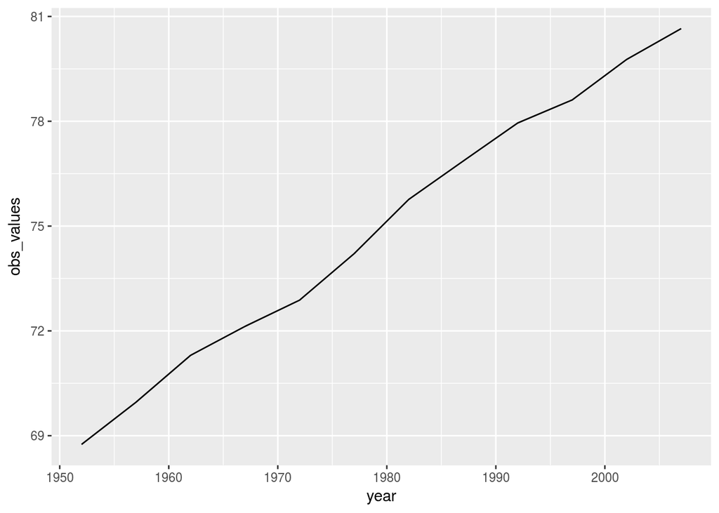

```r
canada_df <- gap_long %>%
  filter(obs_type == 'lifeExp',
         country == 'Canada')

ggplot(canada_df, aes(x = year, y = obs_values)) +
  geom_line()
```

### Check it out in `ggplot`:

Plot life expectancy in all countries in Americas

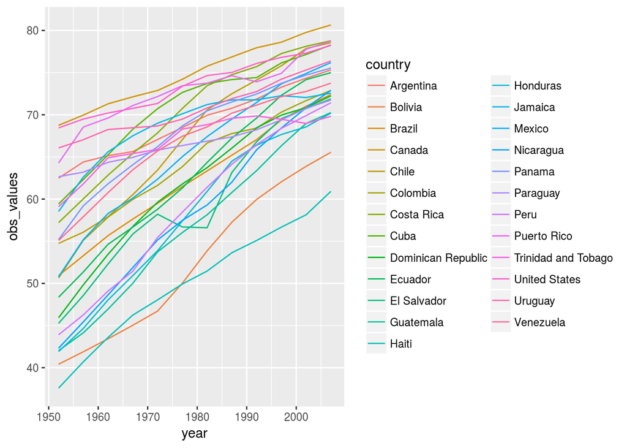

```r
life_df <- gap_long %>%
  filter(continent == "Americas", obs_type == "lifeExp")

ggplot(life_df, aes(x = year, y = obs_values, color = country)) +
  geom_line()
```

### Exercise

Use `gap_long`: * calculate and plot the mean life expectancy for each continent over time from 1982 to 2007 * give your plot a title and assign x and y labels

```r
life_all <- gap_long %>%
  filter(year >= 1982, obs_type == 'lifeExp') %>%
  group_by(continent, year) %>%
  summarize(meanLifeExp = mean(obs_values)) %>%
  ungroup()

head(life_all)
```

```
## # A tibble: 6 x 3
##   continent  year meanLifeExp
##   <chr>     <int>       <dbl>
## 1 Africa     1982        51.6
## 2 Africa     1987        53.3
## 3 Africa     1992        53.6
## 4 Africa     1997        53.6
## 5 Africa     2002        53.3
## 6 Africa     2007        54.8
```

```r
tail(life_all)
```

```
## # A tibble: 6 x 3
##   continent  year meanLifeExp
##   <chr>     <int>       <dbl>
## 1 Oceania    1982        74.3
## 2 Oceania    1987        75.3
## 3 Oceania    1992        76.9
## 4 Oceania    1997        78.2
## 5 Oceania    2002        79.7
## 6 Oceania    2007        80.7
```

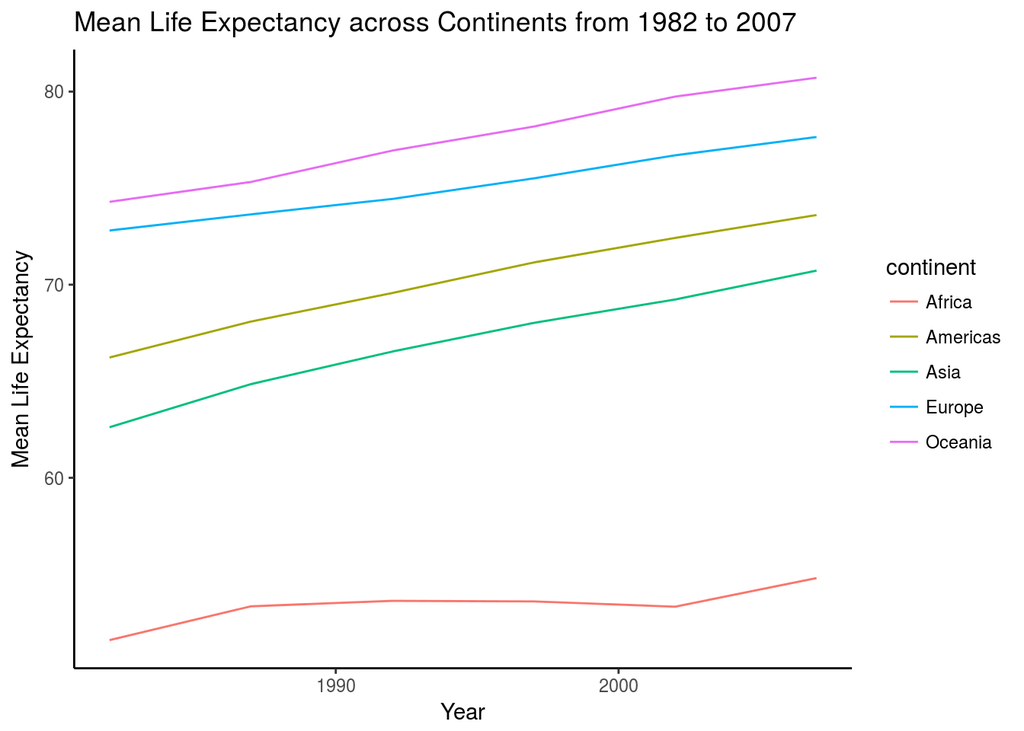

```r
ggplot(life_all, aes(x = year, y = meanLifeExp, color = continent)) +
  geom_line() +
  labs(x = "Year",
       y = "Mean Life Expectancy",
       title = "Mean Life Expectancy across Continents from 1982 to 2007" ) +
  theme_classic()
```